# Counting Rules and Exploratory Data Analysis

To make it more visibly clear we can use the `facet_grid()` function!

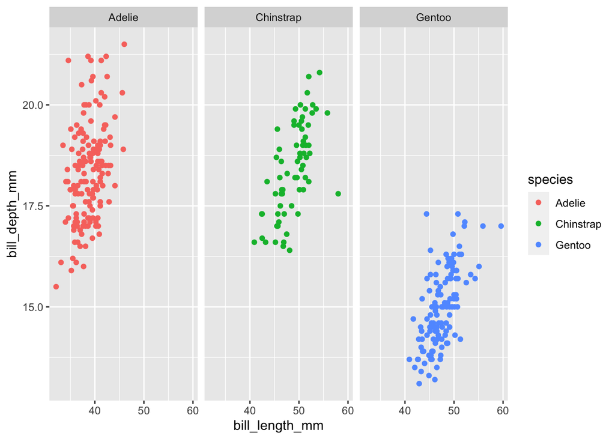

```r
penguins %>% ggplot(aes(x = bill_length_mm, y = bill_depth_mm, colour = species)) +
  geom_point() +
  facet_grid( ~ species)
```

In the last plot the `facet_grid( ~ species)` function splits the dataset into three different datasets according to the category levels in the `species` variable and then creates three seperate plots. So `facet_grid()` is a very powerful graphical tool in your toolbox.

**Task 10:** Now change the colour aesthetic to `sex` in the above graph (instead of the `colour=species`) to find out whether the `bill_length_mm` and `bill_depth_mm` are different based on the sex of a penguin.

```r
# write your code here
```

Now, we want to find whether all three species of penguins can be found in all three islands!

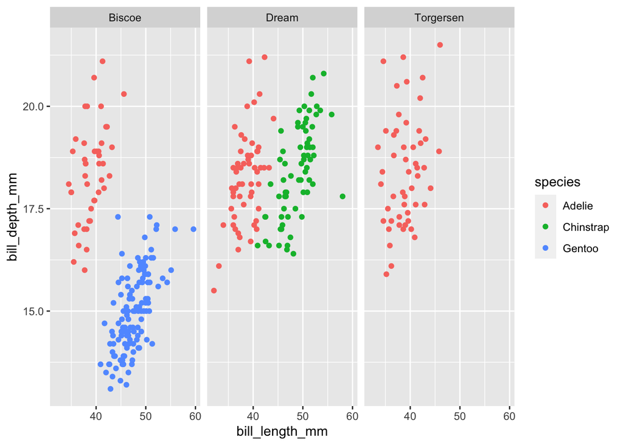

```r
penguins %>% ggplot(aes(x = bill_length_mm, y = bill_depth_mm, colour = species)) +
  geom_point() +
  facet_grid(~ island)
```

From the plot above, you can see the Adelie species can be found on all three islands, Chinstrap can only be found on Dream island and Gentoo can only be found on Biscoe island.

Now, if we want to investigate whether the weight of the penguins are varying over the years we can create a plot as below.

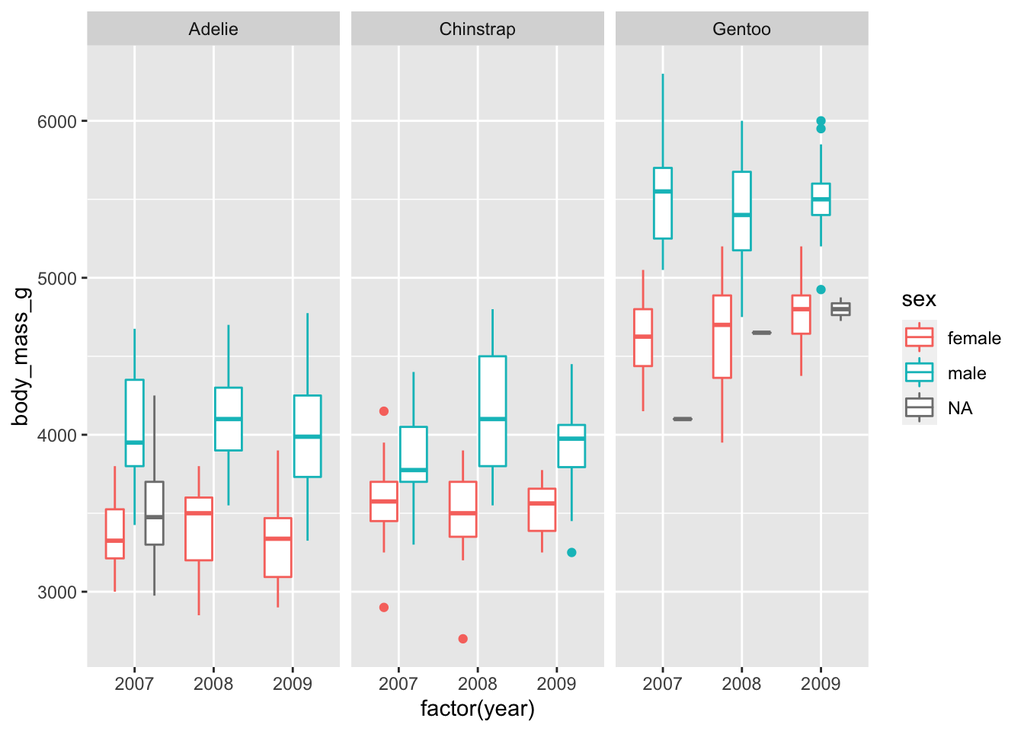

```r
penguins %>% ggplot(aes(y = body_mass_g, x = factor(year), colour = sex)) +
  geom_boxplot() +
  facet_grid(~ species)
```

This plot tells us that in general a male penguin is heavier than a female penguin for all three species. It also tells us that the weight remains the same for each species over the years. It also tells us that the Gentoo species is heavier in general compared to the other species.